# 2018台灣縣市長選舉地圖 and 電動車

Jou Fei Huang

2021/8/3

# Self introduction

[Personal Website](https://joufeihuang.weebly.com/) [My research journey](https://doucelinehuang34.blogspot.com/)

## needed packages

*ggplot2: data visualization*  
sf: for reading and processing spatial data  
*tmap: map*  
tmaptools: for reading and processing spatial data  
*leaflet: for interactive maps*  
dplyr: for data mutation  
*tidyverse: for a lot of necessarily packages for everyday data analyses

sf, tmap are different mapping packages for the same purpose.  
Personally, I like tmap more.

## basic concepts

```r
leaflet()%>%addTiles()
```

[interactive chart not shown]

## import coordinates

```r
setwd("C:/Users/wenra/Downloads")
moto<-readr::read_csv("C:/Users/wenra/Downloads/中油_電動機車充電站.csv")
leaflet()%>%addTiles()%>%
  addCircleMarkers(data=moto,lat=~緯度, lng=~經度,radius=~3)
```

[interactive chart not shown]

## pop-up information

```r
names(moto)
```

```
## [1] "站代號"       "站名"         "郵遞區號"     "地址"         "經度"
## [6] "緯度"         "電話"         "提供服務時段"
```

```r
moto<-moto%>%mutate(popup_info=paste("站名: ",站名,"<br/>",
                           "電話: ", 電話,"<br/>",
                           "提供服務時段: ", 提供服務時段))

motomap<-leaflet()%>%addTiles()%>%addCircleMarkers(data=moto,lat=~緯度, lng=~經度,radius=~3,popup = ~popup_info)
```

## save a map

```r
mapshot(motomap, url = "moto.html")
```

## import data

step 1. Search for shp file.

[Taiwan county map](https://data.moi.gov.tw/MoiOD/Data/DataDetail.aspx?oid=141718DF-0213-48C3-A7F7-AD6222B1D1F2)

Or you can check if any R packages contains map information.

1. world: rnaturalearth
2. USA: usmap

step 2. what do you want to see?

I want to see if DPP won more votes in Southern counties than the KMT.

[Central Election Commission](https://db.cec.gov.tw/)

[主計處 縣市重要統計指標](https://statdb.dgbas.gov.tw/pxweb/Dialog/statfile9.asp)

step 3. check they have a common variable to merge

1. 縣市名稱的寫法是否相同 ex: 台北or 台北市
2. 變數名稱是否相同 ex: countyname or 縣市名稱–>str()

step 4. merge datasets

```r
setwd("C:/Users/wenra/Box Sync/map_taiwan")
taiwan <- st_read("C:/Users/wenra/Box Sync/map_taiwan/COUNTY_MOI_1090820.shp", quiet = TRUE)
str(taiwan)
taiwan<-st_as_sf(taiwan)
countyvote<-readr::read_csv("C:/Users/wenra/Box Sync/map_taiwan/2018_county_mayor_election.csv")
#clean the data

dt_partyvote<-countyvote %>%
  group_by(COUNTYNAME, party) %>%
  summarize(party_vote = vote_ratio)
DPP<-subset(dt_partyvote,party%in%c("民主進步黨"))
KMT<-subset(dt_partyvote,party%in%c("中國國民黨"))

#shp file is always left.
map_DPP<-inner_join(taiwan, DPP)
map_KMT<-inner_join(taiwan, KMT)
names(map_DPP)[names(map_DPP) == "party_vote"] <-"DPP_vote_ratio"
names(map_KMT)[names(map_KMT) == "party_vote"] <-"KMT_vote_ratio"
party2018<-cbind(map_DPP,map_KMT)
class(map_DPP)
str(map_DPP)
```

## draw maps using tmap

*polygons: a closed plane figure bounded by straight lines

This means the 行政區 in this file.

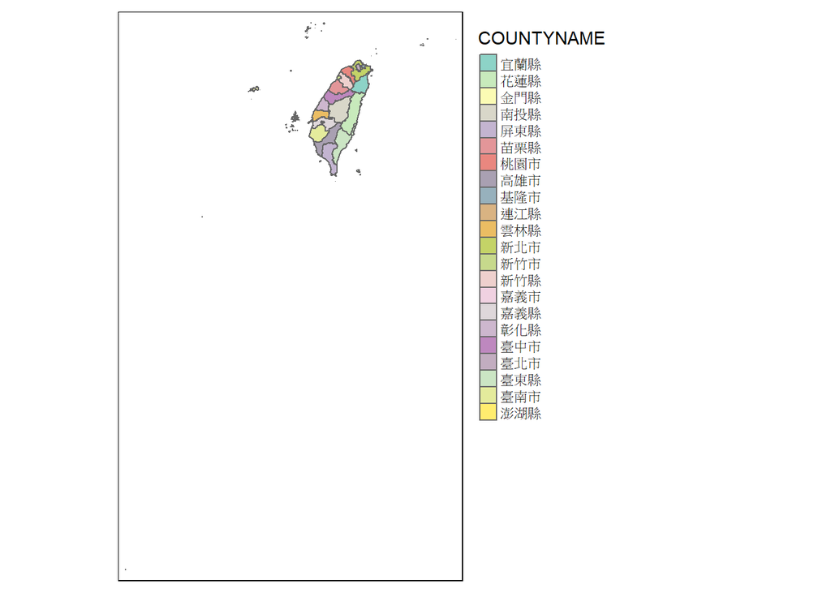

```r
tm_shape(map_DPP) +
  tm_polygons(col = "COUNTYNAME")+
  tm_layout(legend.outside = TRUE)
```

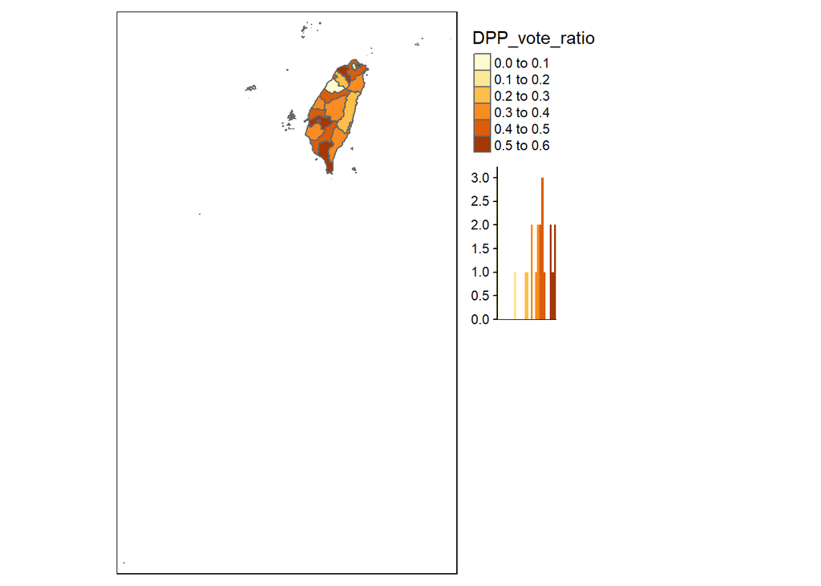

```r
tm_shape(map_DPP) +
  tm_polygons(col = "DPP_vote_ratio",
              legend.hist = TRUE) +
  tm_layout(legend.outside = TRUE)
```

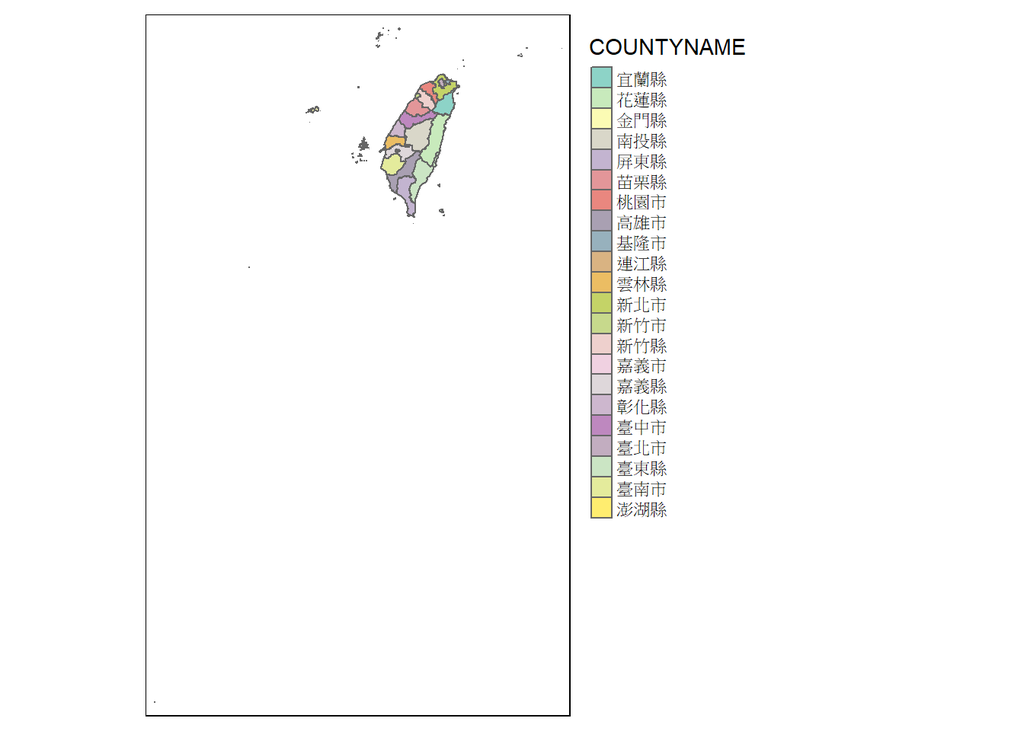

```r
tm_shape(map_KMT) +
  tm_polygons(col = "COUNTYNAME")+
  tm_layout(legend.outside = TRUE)
```

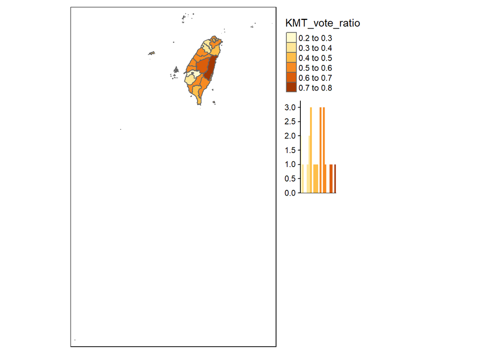

```r
tm_shape(map_KMT) +
  tm_polygons(col = "KMT_vote_ratio",
              legend.hist = TRUE) +
  tm_layout(legend.outside = TRUE)
```

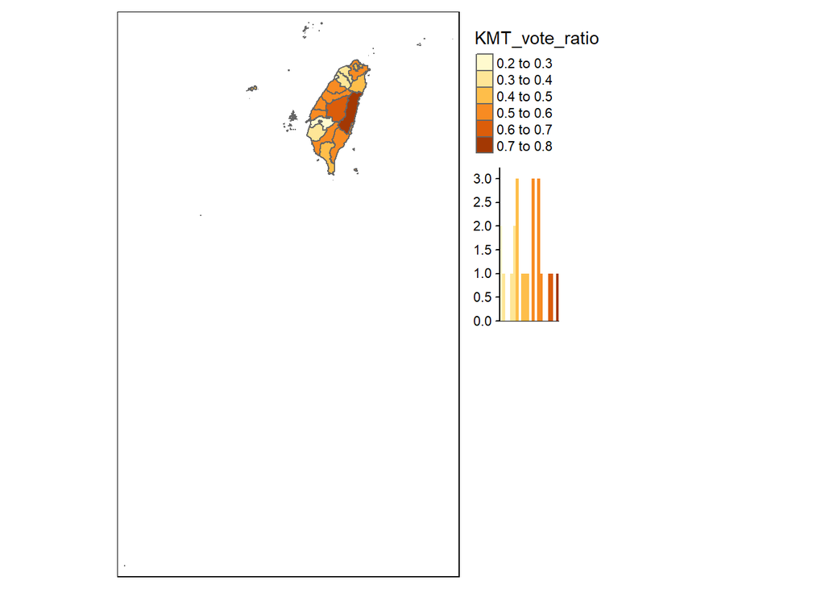

```r
tm_shape(party2018) +
  tm_polygons(col = "KMT_vote_ratio",
              legend.hist = TRUE) +
  tm_layout(legend.outside = TRUE)
```

## draw the map using ggplots

We can also use ggplot to draw a map.  
1)ggplot: dataset  
2)aes: the size of our picture When we paint, we need to decide which kind of paper, color, size of the paper, the layout, and aes helps us define these parameters.

note:

a)aes(geometry = geometry –>so we can make sure that R treats “map_DPP” as spatial data form

b)coord_sf(): not necessary, but if we want Taiwan to be in the center of the map

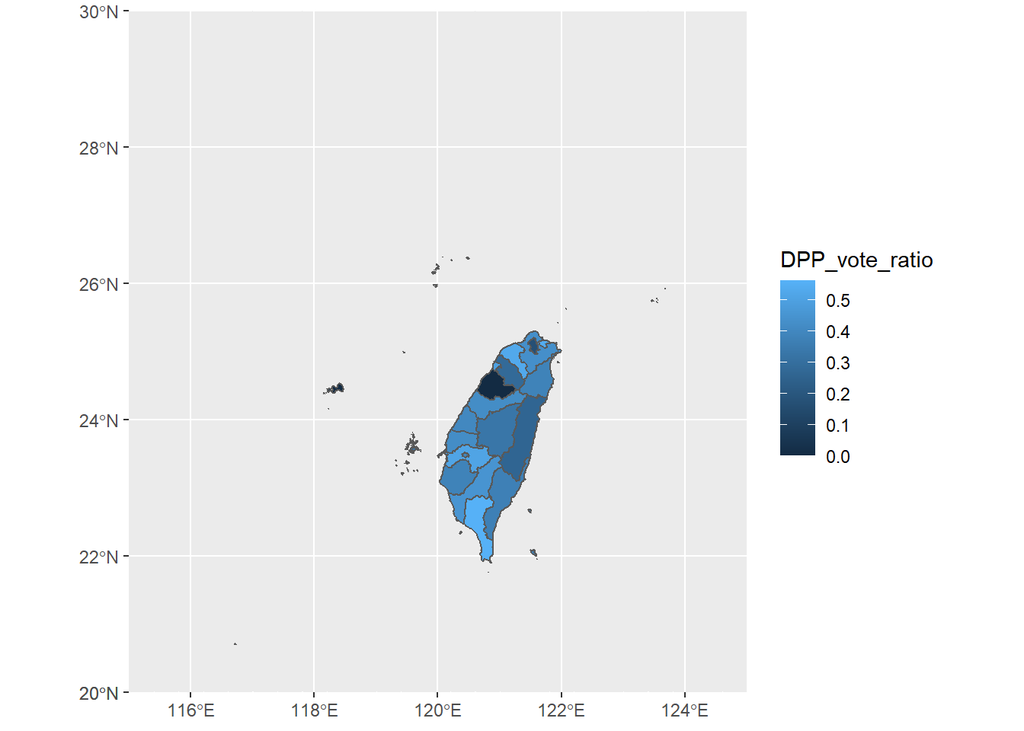

```r
ggplot(map_DPP)+
  geom_sf(aes(geometry = geometry, fill=DPP_vote_ratio))+
  coord_sf(xlim = c(115, 125), ylim = c(20, 30), expand = FALSE)
```

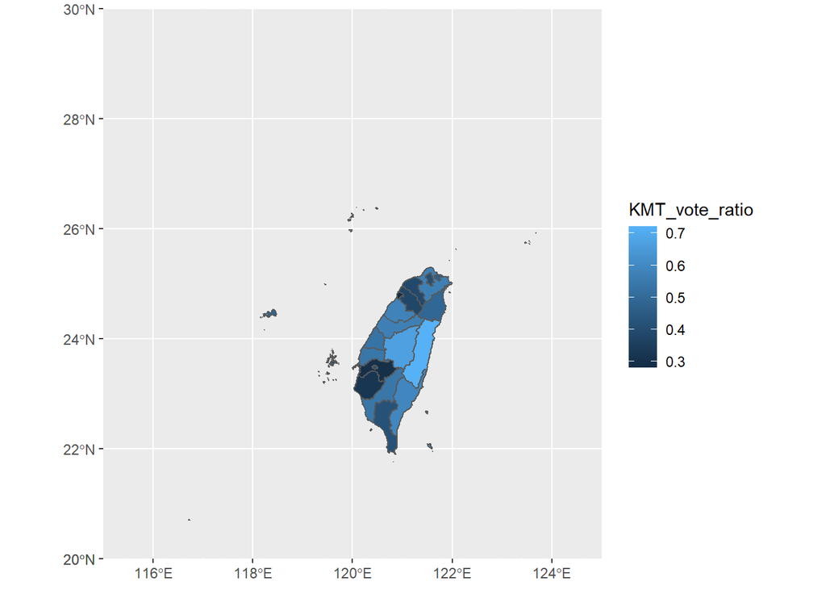

```r
ggplot(map_KMT)+
  geom_sf(aes(geometry = geometry, fill=KMT_vote_ratio))+
  coord_sf(xlim = c(115, 125), ylim = c(20, 30), expand = FALSE)
```

## styles

jenks: identifies groups of similar values in the data and maximizes the differences between categories.

For more kinds of styles:  
https://geocompr.github.io/post/2019/tmap-color-scales/#fn2

style = “pretty”, the default setting, rounds breaks into whole numbers where possible and spaces them evenly;

style = “equal” divides input values into bins of equal range and is appropriate for variables with a uniform distribution (not recommended for variables with a skewed distribution as the resulting map may end-up having little color diversity);

style = “quantile” ensures the same number of observations fall into each category (with the potential downside that bin ranges can vary widely);

style = “jenks” identifies groups of similar values in the data and maximizes the differences between categories;

style = “cont” (and “order”) present a large number of colors over continuous color fields and are particularly suited for continuous rasters (“order” can help visualize skewed distributions);

style = “cat” was designed to represent categorical values and assures that each category receives a unique color.

```r
party2018
```

```
## Simple feature collection with 22 features and 12 fields
## Active geometry column: geometry
## Geometry type: MULTIPOLYGON
## Dimension:     XY
## Bounding box:  xmin: 114.3593 ymin: 10.37135 xmax: 124.5611 ymax: 26.38528
## Geodetic CRS:  TWD97
## First 10 features:
##    COUNTYID COUNTYCODE COUNTYNAME         COUNTYENG      party DPP_vote_ratio
## 1         Z      09007     連江縣 Lienchiang County 民主進步黨           0.00
## 2         G      10002     宜蘭縣      Yilan County 民主進步黨           0.38
## 3         N      10007     彰化縣   Changhua County 民主進步黨           0.40
## 4         M      10008     南投縣     Nantou County 民主進步黨           0.33
## 5         P      10009     雲林縣     Yunlin County 民主進步黨           0.42
## 6         C      10017     基隆市      Keelung City 民主進步黨           0.54
## 7         A      63000     臺北市       Taipei City 民主進步黨           0.17
```

[output cut: 25 more lines]

```r
countyvote$name
```

```
##  [1] "蘇柏豪"                         "朱秀珍"
##  [3] "魏耀乾"                         "劉增應"
##  [5] "楊鎮浯"                         "洪志恒"
##  [7] "汪承樺"                         "陳福海"
##  [9] "謝宜璋"                         "洪和成"
## [11] "林信華"                         "林姿妙"
## [13] "陳歐珀"                         "林錦坤"
## [15] "陳秋境"                         "楊文科"
## [17] "葉芳棟"                         "鄭朝方"
## [19] "徐欣瑩"                         "朱泰平"
## [21] "徐定禎"                         "黃玉燕"
## [23] "徐耀昌"                         "魏明谷"
## [25] "王惠美"                         "白雅燦"
## [27] "黃文玲"                         "洪敏雄"
## [29] "林明溱"                         "洪國浩"
```

[output cut: 33 more lines]

```r
elected<-subset(countyvote,elected==1)
partyelection<- left_join(party2018, elected, by= "COUNTYNAME")
partyelection
```

```
## Simple feature collection with 22 features and 21 fields
## Active geometry column: geometry
## Geometry type: MULTIPOLYGON
## Dimension:     XY
## Bounding box:  xmin: 114.3593 ymin: 10.37135 xmax: 124.5611 ymax: 26.38528
## Geodetic CRS:  TWD97
## First 10 features:
##    COUNTYID COUNTYCODE COUNTYNAME         COUNTYENG    party.x DPP_vote_ratio
## 1         Z      09007     連江縣 Lienchiang County 民主進步黨           0.00
## 2         G      10002     宜蘭縣      Yilan County 民主進步黨           0.38
## 3         N      10007     彰化縣   Changhua County 民主進步黨           0.40
## 4         M      10008     南投縣     Nantou County 民主進步黨           0.33
## 5         P      10009     雲林縣     Yunlin County 民主進步黨           0.42
## 6         C      10017     基隆市      Keelung City 民主進步黨           0.54
## 7         A      63000     臺北市       Taipei City 民主進步黨           0.17
```

[output cut: 47 more lines]

```r
view(partyelection)
```

## create interactive map

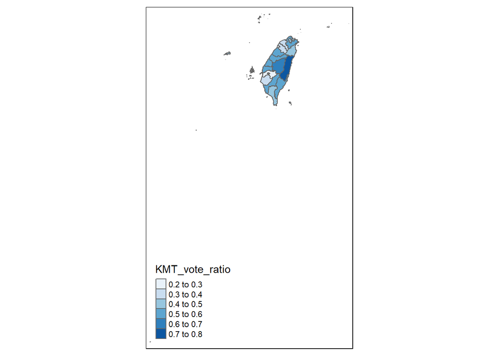

```r
map<-st_as_sf(partyelection)
tm_shape(partyelection)+
  tm_polygons("KMT_vote_ratio",id="COUNTYNAME",palette="Blues",
              popup.vars=c(
                    "2018縣市長國民黨的得票率: "="KMT_vote_ratio",
                    "當選縣市長: " = "name",
                    "當選縣市長的政黨別:"="party.y",
                    "當選者的得票數:"="vote_share")
                )
```

```r
tmap_mode("view")
```

```
## tmap mode set to interactive viewing
```

```r
kmt_2018_countyelection<-tmap_last()
tmap_save(kmt_2018_countyelection,"kmt_2018_countyelection.html")
```

```
## Interactive map saved to C:\Users\wenra\Downloads\kmt_2018_countyelection.html
```